# Lena-ent Pitch Entropy

Kyle MacDonald

```r
library(soundgen)
library(magrittr)
library(tidyverse)
tuneR::setWavPlayer('/usr/bin/afplay')
path_to_wav <- "data/01_raw_data/pilot-ads-ids-segments"
point_color = "darkorange"
model_fit_color = "dodgerblue"
```

## Analyze one wave file

Under the hood of soundgen `analyze()` is the short-time Fourier transform (STFT)

```
* look at one short segment of sound at a time (one STFT frame),
* analyze its spectrum using Fast Fourier Transform (FFT),
* and then move on to the next - perhaps overlapping - frame.
```

As the analysis window slides along the signal, STFT shows which frequencies it contains at different points of time.

First, we grab the audio segments that we want to analyze.

```r
files_to_analyze <- list.files(here::here(path_to_wav))
ads_seg <- files_to_analyze[1]
ids_seg <- files_to_analyze[2]
```

We can listen to a file using the `playme()` function like this:

```r
playme(here::here(path_to_wav, ads_seg))
```

Next, we use the `analyze()` function to generate features about the audio segment.

```r
a_ads <- analyze(x = here::here(path_to_wav, ads_seg),
                 samplingRate =  100, # same sampling rate as Rasanen et al., 2018
                 ylim = c(0.1, 0.8),
                 priorMean = HzToSemitones(300), priorSD = 6)
```

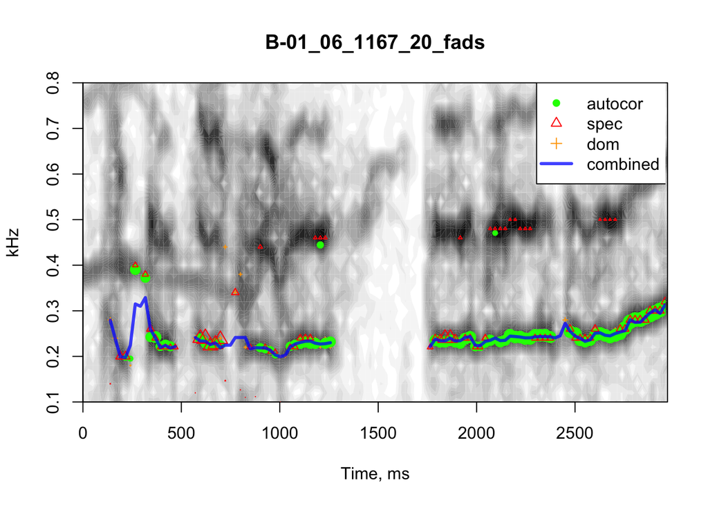

What is median pitch?

```r
a_ads$pitch %>% median(na.rm=T)
```

```
## [1] 237.7334
```

How does pitch of segment change over time?

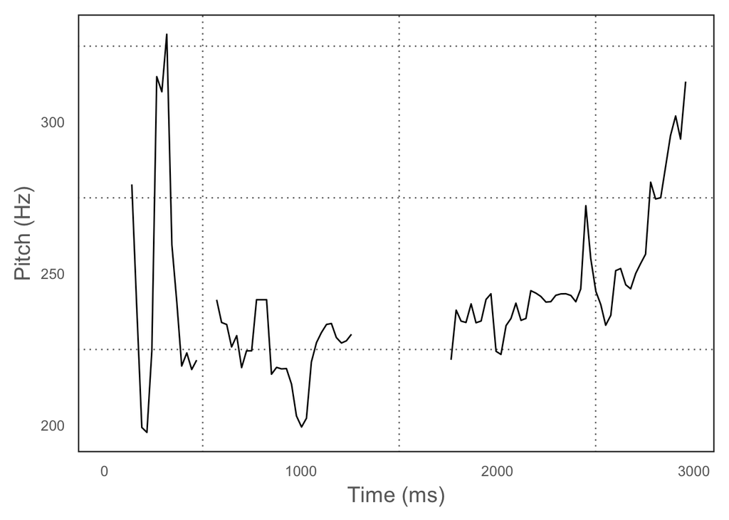

```r
qplot(a_ads$time, a_ads$pitch, geom = 'line') +
  labs(x = "Time (ms)", y = "Pitch (Hz)")
```

### IDS segment

```r
playme(here::here(path_to_wav, ids_seg))
```

```r
lowest_pitch <- 75
highest_pitch <- 1000
sampling_rate <- 100 # same sampling rate as Rasanen et al., 2018
hz_lims <- c(0.1, 0.8)

a_ids <- analyze(x = here::here(path_to_wav, ids_seg),
                 samplingRate =  sampling_rate,
                 pitchFloor = lowest_pitch, pitchCeiling = highest_pitch,
                 ylim = hz_lims,
                 showLegend = FALSE)
```

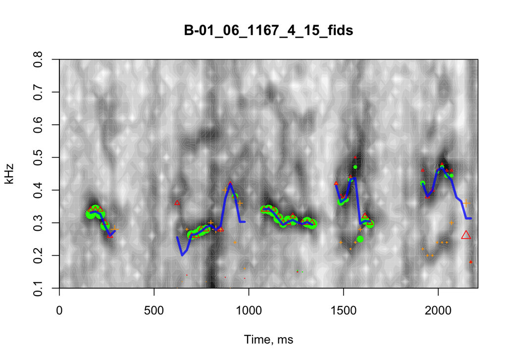

```r
# Store pitch tracking information in a tibble
d_pitch <- tibble(
  segment_type = 'ids',
  pitch = a_ids$pitch,
  time_utt_ms = a_ids$time
)
```

#### Fit a second order polynomial to the F0 trajectory in time.

First we have to interpolate between regions of the audio segment that did not have pitch measurements (i.e., unvoiced speech).

To do this we can use the `cubicspline()` function from the pracma package.

```r
x <- d_pitch %>% filter(!is.na(pitch)) %>% pull(time_utt_ms)
y <- d_pitch %>% filter(!is.na(pitch)) %>% pull(pitch)

pp <- pracma::cubicspline(x, y)
ppfun <- function(x) {pracma::ppval(pp, x)}
```

We also log transform the pitch values because people’s perception of pitch change logarithmically.

```r
d_pitch %<>%
  mutate(pitch_int = ppfun(time_utt_ms),
         log_pitch = log(pitch),
         z_log_pitch = scale(log_pitch))

# check z score worked
d_pitch$z_log_pitch %>% mean(na.rm = T)
```

```
## [1] -7.496583e-16
```

```r
d_pitch$z_log_pitch %>% sd(na.rm = T)
```

```
## [1] 1
```

Plot the interpolation function.

```r
a <- d_pitch %>%
  filter(time_utt_ms >= min(x),
         time_utt_ms <= max(x)) %>%
  ggplot() +
  geom_line(aes(x = time_utt_ms, y = pitch_int), color = model_fit_color, size = 1) +
  #geom_point(aes(x = time_utt_ms, y = pitch_int), color = 'darkred') +
  geom_point(aes(x = time_utt_ms, y = pitch), size = 3, color = point_color) +
  lims(y = c(0, 700)) +
  labs(x = "Time (ms)", y = "Pitch (Hz)", title = "Cubic Spline")
```

Hmm, this looks a lot wigglier than the interpolated points in the Rasanen paper. They also used 30-ms median filtering to the resulting pitch tracks to remove single outlier values.

### Interpolation using loess

```r
# Use span to control the "wiggliness" of the default loess smoother.
# The span is the fraction of points used to fit each local regression:
# small numbers make a wigglier curve, larger numbers make a smoother curve.

frac_points <- 0.18

b <- d_pitch %>%
  filter(time_utt_ms >= min(x),
         time_utt_ms <= max(x)) %>%
  ggplot() +
  geom_smooth(aes(x = time_utt_ms, y = pitch), span = frac_points, se = F,
              color = "dodgerblue") +
  #geom_line(aes(x = time_utt_ms, y = pitch_int), color = 'darkgrey', size = 1) +
  #geom_point(color = 'blue') +
  geom_point(aes(x = time_utt_ms, y = pitch), size = 3, color = 'darkorange') +
  lims(y = c(0, 700)) +
  labs(x = "Time (ms)", y = "Pitch (Hz)") +
  labs(title ="Loess Fit")
```

Plot the two intrporolation functions next to each other

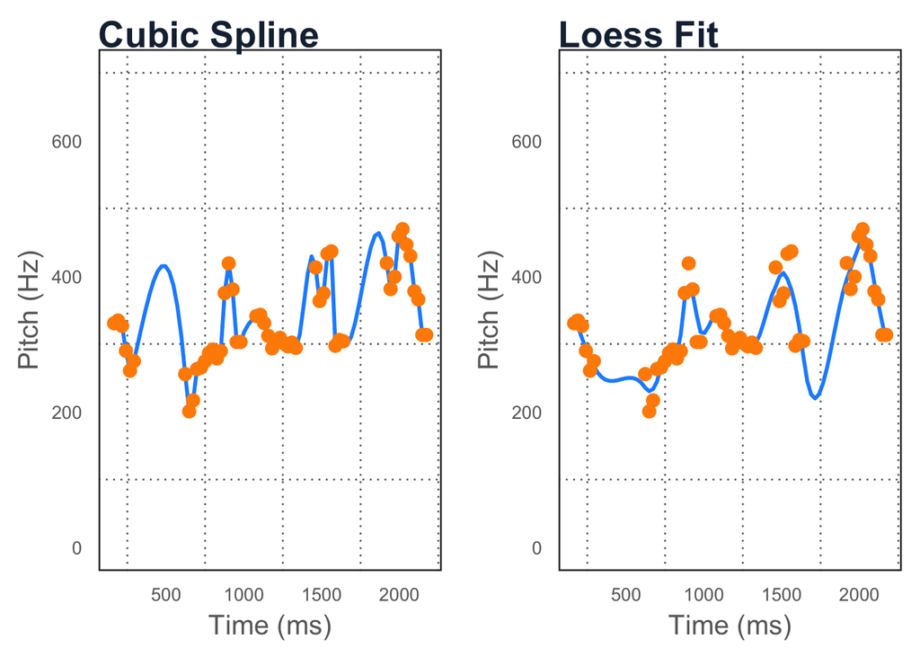

```r
cowplot::plot_grid(a, b)
```

Next, we can make the same plot but using the log transformed and normalized pitch values.

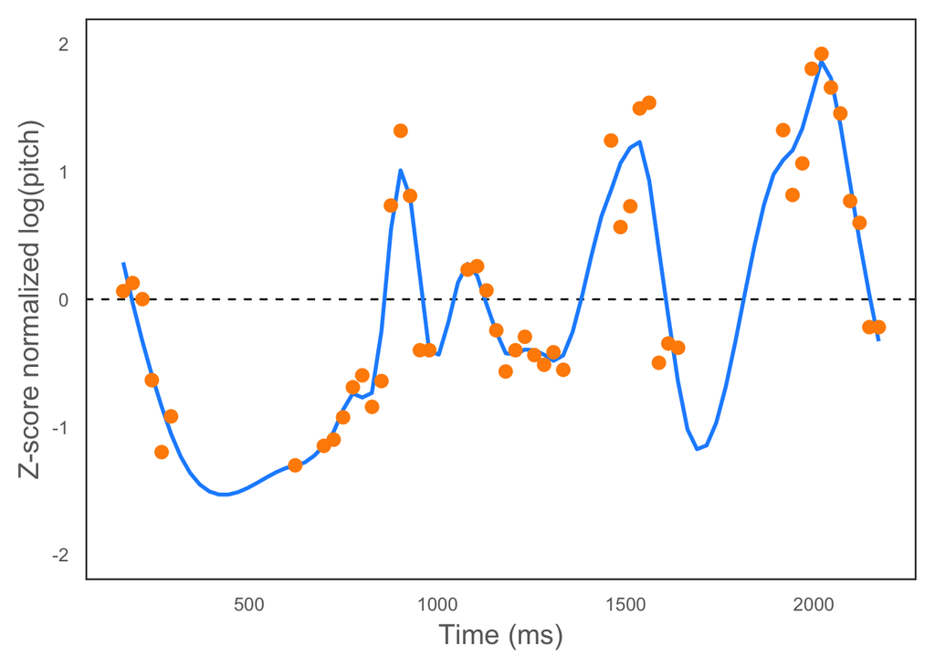

```r
d_pitch %>%
  filter(time_utt_ms >= min(x),
         time_utt_ms <= max(x)) %>%
  ggplot(aes(x = time_utt_ms, y = z_log_pitch)) +
  geom_hline(yintercept = 0, lty = "dashed") +
  geom_smooth(span = frac_points, se = F, color = model_fit_color) +
  geom_point(color = point_color, size = 3) +
  labs(x = "Time (ms)", y = "Z-score normalized log(pitch)") +
  lims(y = c(-2,2)) +
  theme(panel.grid = element_blank())
```

### Sample entropy

```r
# define the model
m_loess <- loess(z_log_pitch ~ time_utt_ms, span = frac_points,
                 data = d_pitch)


# predict fitted values for each observation in the original dataset
df_preds <- predict(m_loess,
                    newdata = d_pitch,
                    se = TRUE) %>%
  data.frame()
```

Calculate sample entropy of the interpolated pitch contour. Sample entropy was introduced to quantify the the amount of regularity and the unpredictability of fluctuations in a time series. A low value of the entropy indicates that the time series is deterministic; a high value indicates randomness.

```r
samp_ent_ids <- df_preds %>%
  filter(!is.na(fit)) %>%
  pull(fit) %>%
  pracma::sample_entropy() %>%
  round(2)
```

Plot the predicted values from the loess model.

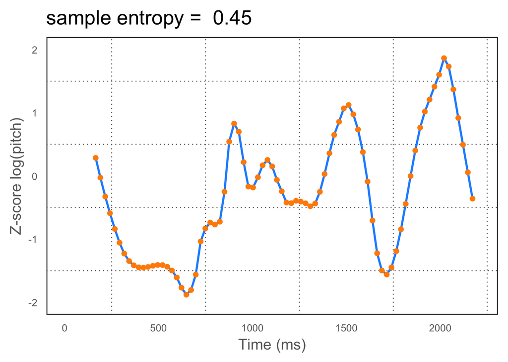

```r
loess_preds_ids <- df_preds %>%
  mutate(time = d_pitch$time_utt_ms) %>%
  ggplot(aes(x = time, y = fit)) +
  geom_line(color = model_fit_color, size = 1) +
  geom_point(color = point_color, size = 2) +
  labs(x = "Time (ms)", y = "Z-score log(pitch)",
       subtitle = paste('sample entropy = ', samp_ent_ids)) +
  lims(y = c(-2,2))

loess_preds_ids
```

[figure not shown]

```r
# extract pitch contour
d_pitch_ads <- tibble(
  segment_type = 'ads',
  pitch = a_ads$pitch,
  time_utt_ms = a_ads$time
)

# interpolate, log transform, and z-score
d_pitch_ads %<>%
  mutate(pitch_int = ppfun(time_utt_ms),
         log_pitch = log(pitch),
         z_log_pitch = scale(log_pitch))

# define the model
m_loess_ads <- loess(z_log_pitch ~ time_utt_ms, span = frac_points,
                 data = d_pitch_ads)


# predict fitted values for each observation in the original dataset
df_preds_ads <- predict(m_loess_ads,
                    newdata = d_pitch_ads,
                    se = TRUE) %>%
  data.frame()

# calculate entropy
samp_ent <- df_preds_ads %>%
  filter(!is.na(fit)) %>%
  pull(fit) %>%
  pracma::approx_entropy() %>%
  round(2)

# plot
loess_preds_ads <- df_preds_ads %>%
  mutate(time = d_pitch_ads$time_utt_ms) %>%
  ggplot(aes(x = time, y = fit)) +
  geom_line(color = model_fit_color, size = 1) +
  geom_point(color = point_color, size = 2) +
  labs(x = "Time (ms)", y = "Z-score log(pitch)",
       subtitle = paste('sample entropy = ', samp_ent)) +
  lims(y = c(-2,2))

loess_preds_ads
```

Plot IDS and ADS curves next to each other:

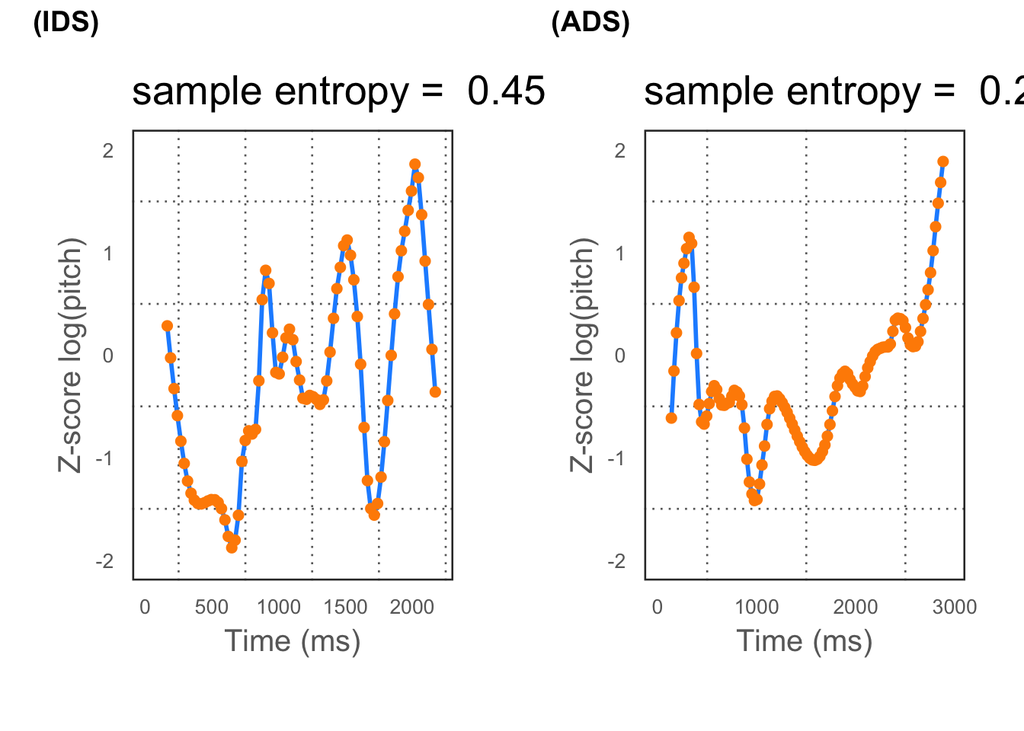

```r
cowplot::plot_grid(loess_preds_ids, loess_preds_ads,
                   labels = c('(IDS)', '(ADS)'),
                   scale = 0.85)
```

### Fixed frame temporal segmentation

Here we replicate the approach of using uniformly spaced segments where F0 was sampled and predicted at regular intervals. Following, Rasanen et al., 2018 we use 100-ms non-overlapping segments.

> Voicing information was used to determine the first and last valid segment of each utterance.

### Polynomial fit to the F0 trajectory in each time bin

```r
 p <- pracma::polyfit(x, y, 2)
```

### Vector quantisation of curves in each segment

## Modifying the settings of analyze function

```
* windowLength: the length of sliding STFT window. Longer windows (e.g., 40 - 50 ms) improve frequency resolution at the expense of time resolution, so they are good for detecting relatively low, slowly changing F0, as in human moans or grunts. Shorter windows (e.g., 5 - 10 ms) improve time resolution at the expense of frequency resolution, so they are good for visualizing formants or tracking high-frequency, rapidly changing F0 as in bird chirps or dolphin whistles.

* step: the step of sliding STFT window. For example, if windowLength = 50 and step = 25, each time we move the analysis frame, there is a 50% overlap with the previous frame. This introduces redundancy into the analysis, but it also - to some limited extent - improves time resolution while maintaining relatively high frequency resolution. The main cost of small steps (large overlap) is processing time, but very large overlap is not always desirable, even when processing time is not an issue. If some audio segments are problematic (e.g., very noisy), pitch contour may actually be more accurate with relatively large steps and more smoothing. It is therefore best to check the results with different steps and/or run formal optimization (remember to adjust smoothing and other postprocessing parameters together with STFT settings)

* wn: the type of windowing function used to taper the analysis frame during STFT. In practice the windowing function doesn’t seem to have a major effect on the result, as long as you choose something reasonable like gaussian, hanning, or bartlett.

* zp: zero-padding. You can use a short STFT window and improve its frequency resolution by padding each frame with zeroes. This is a computational trick that - again, to some limited extent - improves frequency resolution while maintaining relatively high time resolution.

* silence: frames with root mean square (RMS) amplitude below silence threshold are not analyzed at all. Quiet frames are harder to analyze, because their signal-to-noise ratio is lower. As a result, we want to strike a good balance. Setting silence too low (close to 0) produces a lot of garbage, as the algorithm tries to analyze frames that are essentially just background noise without any signal. Setting silence too high (close to 1) excludes too many perfectly good frames, misrepresenting the signal.
```